# Sleep Health and Lifestyle Data Analysis

Chiao Yu Huang

2024-11-16

# Introduction

In this project, I will analyze “Sleep Health and Lifestyle” dataset. This dataset provides a comprehensive view of how various factors influence sleep and overall well-being. It consists of 400 observations across 13 variables, including age, gender, occupation, BMI, blood pressure, heart rate, daily steps, the presence or absence of sleep disorders and so on. The objectives include: * To explore the key variables through summary statistics * To analyze how different lifestyle factors affect sleep quality * To Visualize the relationships between sleep health and other lifestyle factors

```r
# Install the Kaggle API
system("pip install kaggle")
system("kaggle datasets download -d uom190346a/sleep-health-and-lifestyle-dataset")
system("unzip sleep-health-and-lifestyle-dataset.zip")
```

```r
# Load the dataset into R
slp <- read.csv("data/Sleep_health_and_lifestyle_dataset.csv")
View(slp)
```

# Descriptive Statistics

Through creating a summary table, we can have a clearer idea of dataset.

```r
install.packages("knitr")
library(knitr)

# Summary statistics
summary_slp <- data.frame(
  Variable = c("Age", "Sleep.Duration", "Physical.Activity.Level"),
  Mean = c(mean(slp$Age, na.tm = TRUE), mean(slp$Sleep.Duration, na.rm=TRUE), mean(slp$Physical.Activity.Level, na.rm=TRUE)),
  Median = c(median(slp$Age, na.rm = TRUE), median(slp$Sleep.Duration, na.rm = TRUE), median(slp$Physical.Activity.Level, na.rm = TRUE)),
  SD = c(sd(slp$Age, na.rm = TRUE), sd(slp$Sleep.Duration, na.rm = TRUE), sd(slp$Physical.Activity.Level, na.rm = TRUE))
)

# Display a table
kable(summary_slp, caption = "Summary of Key Variables")
```

Summary of Key Variables

| Variable | Mean | Median | SD |
| --- | --- | --- | --- |
| Age | 42.184492 | 43.0 | 8.6731335 |
| Sleep.Duration | 7.132086 | 7.2 | 0.7956567 |
| Physical.Activity.Level | 59.171123 | 60.0 | 20.8308037 |

## Description of the table

The table above shows the mean, median and standard deviation for three keys variables: Age, Sleep Duration and Physical Activity. It indicates the average sleep duration in the population and the variability in physical activity levels.

# Figure_1: Sleep duration by occupation

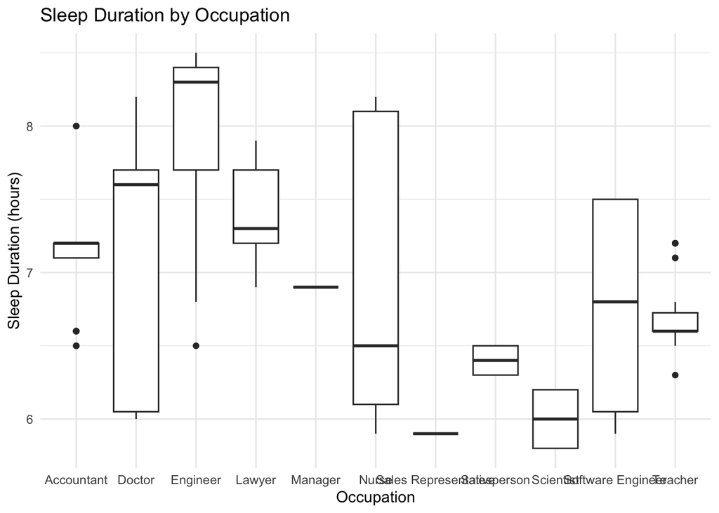

```r
library(ggplot2)

# Plot sleep duration by occupation
ggplot(slp, aes(x=factor(Occupation), y=Sleep.Duration)) +
  geom_boxplot() +
  labs(title = "Sleep Duration by Occupation",
       x = "Occupation",
       y = "Sleep Duration (hours)") +
  theme_minimal()
```